# W3cubDocs

/scikit-learn

# train_test_split

**sklearn.model_selection.train_test_split(*arrays, *test_size=None*, *train_size=None*, *random_state=None*, *shuffle=True*, *stratify=None*)[[source]](https://github.com/scikit-learn/scikit-learn/blob/99bf3d8e4/sklearn/model_selection/_split.py#L2734)**

Split arrays or matrices into random train and test subsets.

Quick utility that wraps input validation, `next(ShuffleSplit().split(X, y))`, and application to input data into a single call for splitting (and optionally subsampling) data into a one-liner.

Read more in the User Guide.

**Parameters:**

**arrayssequence of indexables with same length / shape[0]**

Allowed inputs are lists, numpy arrays, scipy-sparse matrices or pandas dataframes.

**test_size**float or int, default=None**

If float, should be between 0.0 and 1.0 and represent the proportion of the dataset to include in the test split. If int, represents the absolute number of test samples. If None, the value is set to the complement of the train size. If `train_size` is also None, it will be set to 0.25.

**train_size**float or int, default=None**

If float, should be between 0.0 and 1.0 and represent the proportion of the dataset to include in the train split. If int, represents the absolute number of train samples. If None, the value is automatically set to the complement of the test size.

**random_state**int, RandomState instance or None, default=None**

Controls the shuffling applied to the data before applying the split. Pass an int for reproducible output across multiple function calls. See [Glossary](https://scikit-learn.org/1.6/glossary.html#term-random_state).

**shuffle**bool, default=True**

Whether or not to shuffle the data before splitting. If shuffle=False then stratify must be None.

**stratify**array-like, default=None**

If not None, data is split in a stratified fashion, using this as the class labels. Read more in the User Guide.

**Returns:**

**splitting**list, length=2 * len(arrays)**

List containing train-test split of inputs.

Added in version 0.16: If the input is sparse, the output will be a `scipy.sparse.csr_matrix`. Else, output type is the same as the input type.

#### Examples

```
>>> import numpy as np
>>> from sklearn.model_selection import train_test_split
>>> X, y = np.arange(10).reshape((5, 2)), range(5)
>>> X
array([[0, 1],
       [2, 3],
       [4, 5],
       [6, 7],
       [8, 9]])
>>> list(y)
[0, 1, 2, 3, 4]
```

```
>>> X_train, X_test, y_train, y_test = train_test_split(
...     X, y, test_size=0.33, random_state=42)
...
>>> X_train
array([[4, 5],
       [0, 1],
       [6, 7]])
>>> y_train
[2, 0, 3]
>>> X_test
array([[2, 3],
       [8, 9]])
>>> y_test
[1, 4]
```

```
>>> train_test_split(y, shuffle=False)
[[0, 1, 2], [3, 4]]
```

## Gallery examples

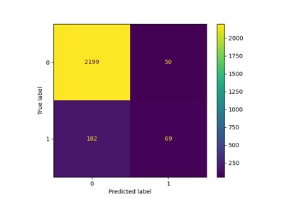

Release Highlights for scikit-learn 1.5

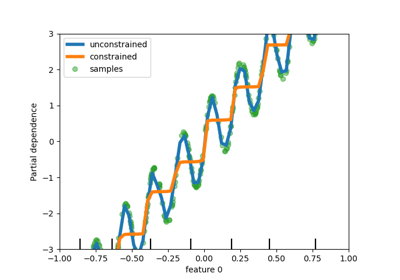

Release Highlights for scikit-learn 1.4

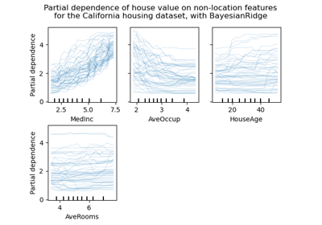

Release Highlights for scikit-learn 0.24

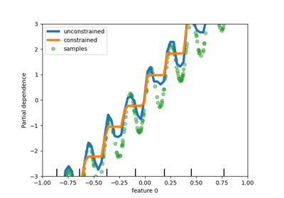

Release Highlights for scikit-learn 0.23

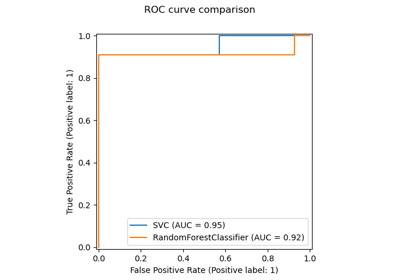

Release Highlights for scikit-learn 0.22

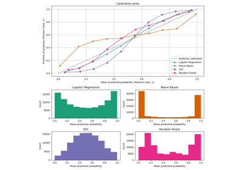

Comparison of Calibration of Classifiers

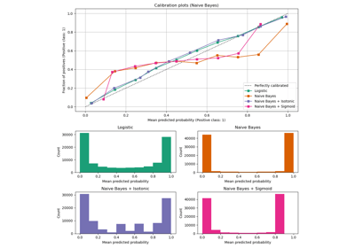

Probability Calibration curves

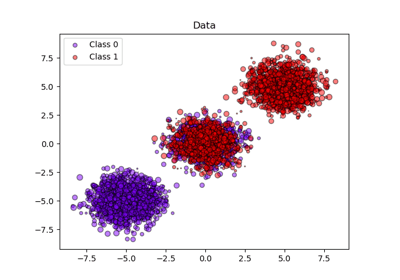

Probability calibration of classifiers

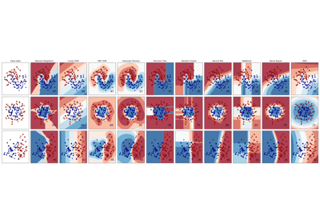

Classifier comparison

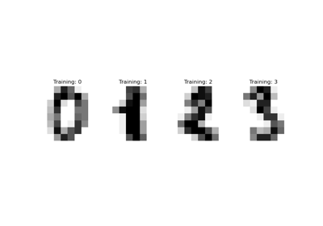

Recognizing hand-written digits

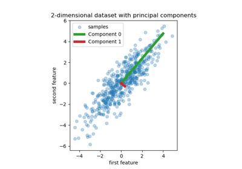

Principal Component Regression vs Partial Least Squares Regression

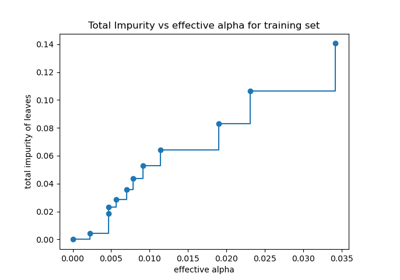

Post pruning decision trees with cost complexity pruning

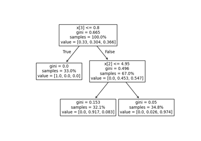

Understanding the decision tree structure

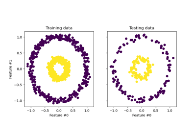

Kernel PCA

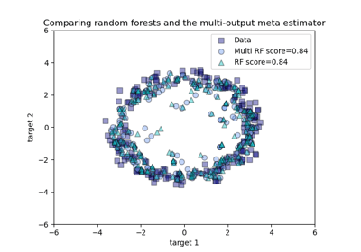

Comparing random forests and the multi-output meta estimator

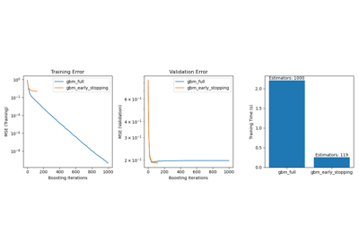

Early stopping in Gradient Boosting

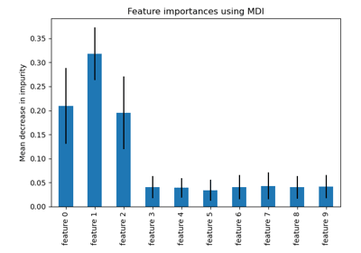

Feature importances with a forest of trees

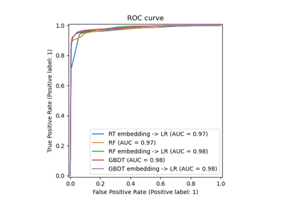

Feature transformations with ensembles of trees

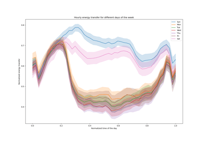

Features in Histogram Gradient Boosting Trees

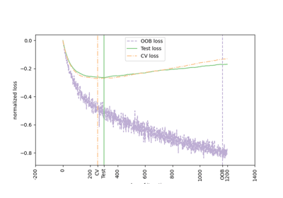

Gradient Boosting Out-of-Bag estimates

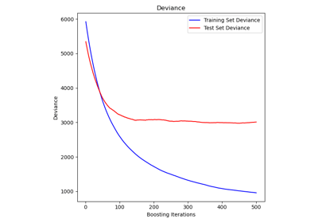

Gradient Boosting regression

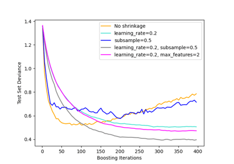

Gradient Boosting regularization

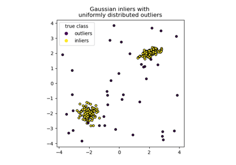

IsolationForest example

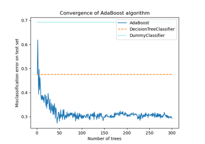

Multi-class AdaBoosted Decision Trees

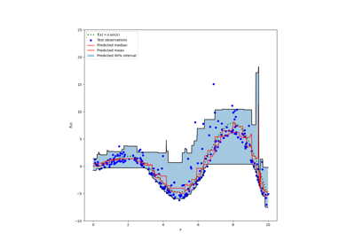

Prediction Intervals for Gradient Boosting Regression

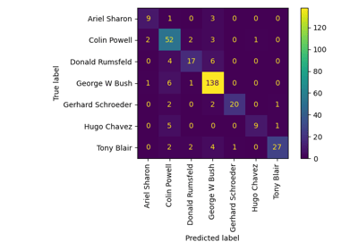

Faces recognition example using eigenfaces and SVMs

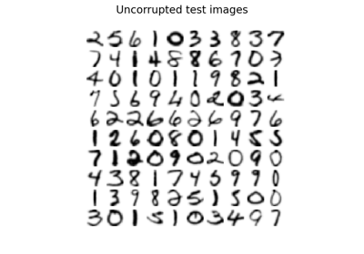

Image denoising using kernel PCA

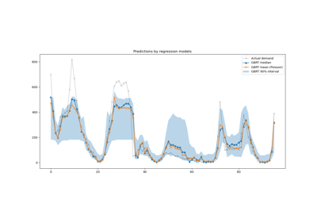

Lagged features for time series forecasting

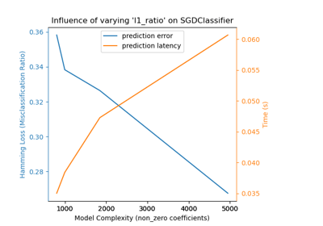

Model Complexity Influence

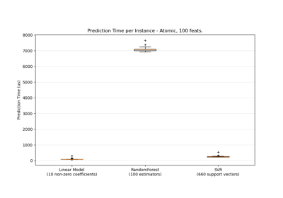

Prediction Latency

Pipeline ANOVA SVM

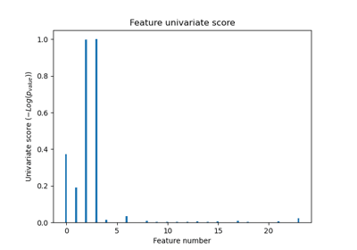

Univariate Feature Selection

Examples of Using FrozenEstimator

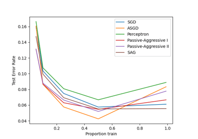

Comparing various online solvers

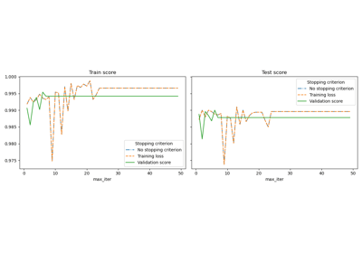

Early stopping of Stochastic Gradient Descent

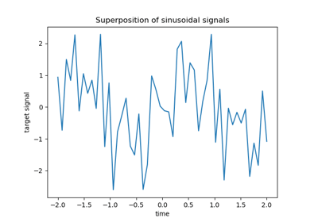

L1-based models for Sparse Signals

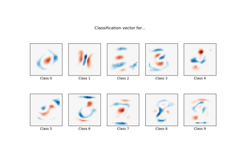

MNIST classification using multinomial logistic + L1

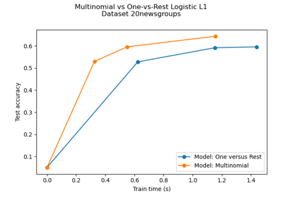

Multiclass sparse logistic regression on 20newgroups

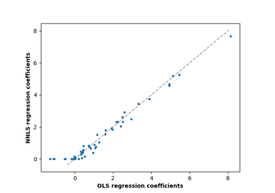

Non-negative least squares

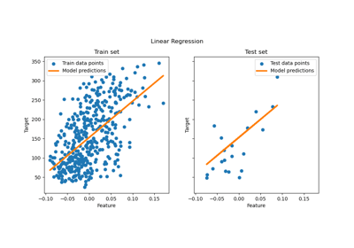

Ordinary Least Squares Example

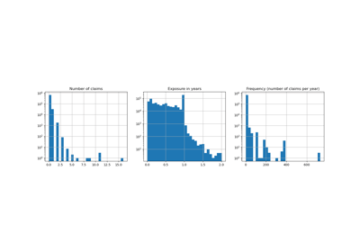

Poisson regression and non-normal loss

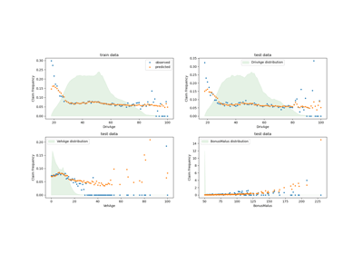

Tweedie regression on insurance claims

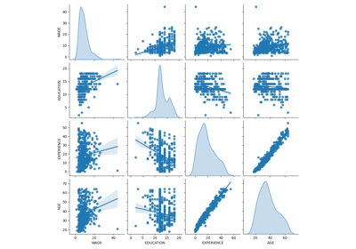

Common pitfalls in the interpretation of coefficients of linear models

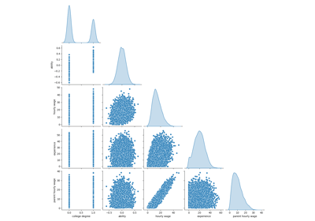

Failure of Machine Learning to infer causal effects

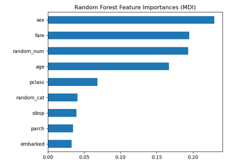

Permutation Importance vs Random Forest Feature Importance (MDI)

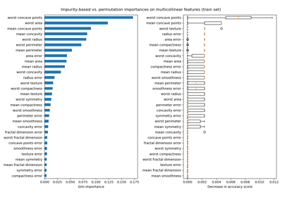

Permutation Importance with Multicollinear or Correlated Features

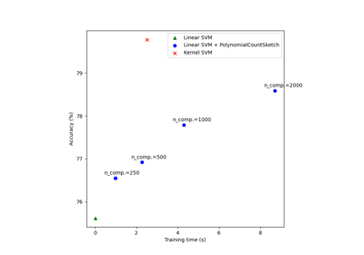

Scalable learning with polynomial kernel approximation

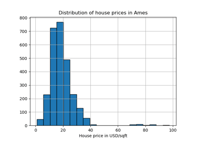

Evaluation of outlier detection estimators

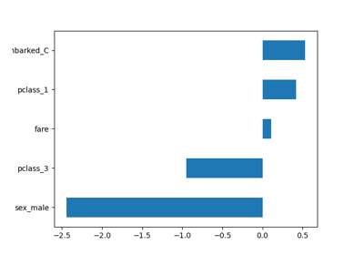

Introducing the set_output API

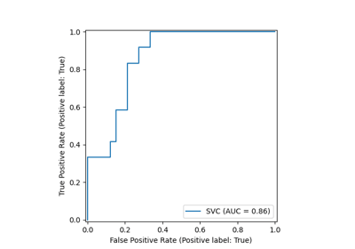

ROC Curve with Visualization API

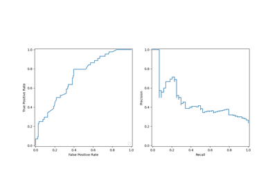

Visualizations with Display Objects

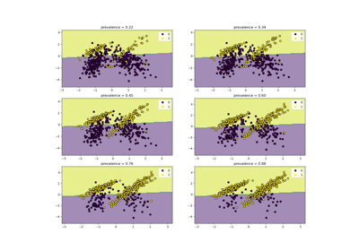

Class Likelihood Ratios to measure classification performance

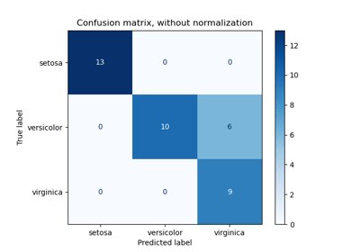

Confusion matrix